# 建材销售分析报告

——无锡本地某建材批发商 19 年销售数据的深度探索

！此版本为Public版，使用数据集sales_anonymized.xlsx，仅保留了原有的商品大类、名称、编码、规格，其中的商品价格、出货数量已经过扰动处理，客户名、客户隐私已经过严格脱敏处理，因此部分原始数据、统计量、表格、图例与原版会有些出入。但仍然非常具有分析价值。

本报告基于无锡本地某建材批发商 **19 年（2007-07 ~ 2026-08）** 的销售业务数据，进行探索性数据分析（EDA），覆盖订单明细、商品、客户与收付款全链路信息。全文分析基于清洗后数据（口径见第一部分），数值与原始数据有差异时以清洗后为准。

## 数据集概览

- **数据规模**：原始 94,550 行 → 清洗后 **89,593 行**订单明细、16,466 张单据、19 年时间跨度（2012 年起为完整年度，可逐年对比）
- **覆盖范围**：**1,298 家真实客户**（另含"零售"占位）、**36 个商品品类**、**978 个 SKU**

## 一、数据治理与清洗

|  | 商品大类 | 商品名称 | 商品规格 | 商品编码 | 出货日期 | 出货数量 | 商品单价 | 折扣率 | 折后单价 | 合计 | 已付金额 | 欠款金额 | 客户 | 出货人 | 单据号 | 仓库 | 付款方式 |
| --- | --- | --- | --- | --- | --- | --- | --- | --- | --- | --- | --- | --- | --- | --- | --- | --- | --- |
| 0 | 邓禄普系列 | 强力型瓷砖粘结剂 | 20公斤 | 880 | 2026-08-18 | 1 | 37.22 | 1.0 | 0.00 | 0.00 | 0.00 | 0.00 | 客户001 | 超级用户 | SO-000001 | 总仓库 | 现金结账 |
| 1 | 邓禄普系列 | 强力型瓷砖粘结剂 | 20公斤 | 880 | 2026-08-18 | 18 | 37.22 | 1.0 | 26.05 | 468.90 | 0.00 | 468.90 | 客户001 | 超级用户 | SO-000001 | 总仓库 | 现金结账 |
| 2 | 晨阳水漆系列 | 骄阳易居 | 24公斤 | 1243 | 2026-08-18 | 75 | 119.85 | 1.0 | 70.82 | 5311.50 | 0.00 | 5311.50 | 客户002 | 超级用户 | NaN | 总仓库 | 现金结账 |
| 3 | 邓禄普系列 | 双组份柔性防水浆料 | 18公斤蓝色 | 882 | 2026-08-18 | 11 | 160.58 | 1.0 | 155.23 | 1707.53 | 1433.82 | 273.71 | 客户003 | 超级用户 | SO-000002 | 总仓库 | 现金结账 |
| 4 | 邓禄普系列 | 1+1柔性防水砂浆 | 20公斤，蓝 | 829 | 2026-08-18 | 12 | 343.80 | 1.0 | 167.13 | 2005.56 | 1674.72 | 330.84 | 客户003 | 超级用户 | SO-000002 | 总仓库 | 现金结账 |
| 5 | 邓禄普系列 | 界面剂及水泥砂浆增强剂 | 5公斤 | 805 | 2026-08-18 | 1 | 98.53 | 1.0 | 0.00 | 0.00 | 0.00 | 0.00 | 客户004 | 1 | NaN | 总仓库 | NaN |
| 6 | 邓禄普系列 | 界面剂及水泥砂浆增强剂 | 5公斤 | 805 | 2026-08-18 | 14 | 98.53 | 1.0 | 0.00 | 0.00 | 0.00 | 0.00 | 客户005 | 1 | SO-000003 | 总仓库 | NaN |
| 7 | 邓禄普系列 | 强效水泥砂浆增强剂 | 20公斤 | 875 | 2026-08-18 | 1 | 354.48 | 1.0 | 0.00 | 0.00 | 0.00 | 0.00 | 客户005 | 1 | SO-000003 | 总仓库 | NaN |
| 8 | 邓禄普系列 | 强效水泥砂浆增强剂 | 20公斤 | 875 | 2026-08-18 | 25 | 354.48 | 1.0 | 288.65 | 7216.25 | 0.00 | 7216.25 | 客户005 | 1 | SO-000003 | 总仓库 | NaN |
| 9 | 邓禄普系列 | 界面剂及水泥砂浆增强剂 | 5公斤 | 805 | 2026-08-18 | 4 | 98.53 | 1.0 | 88.16 | 352.64 | 0.00 | 352.64 | 客户006 | 超级用户 | NaN | 总仓库 | 现金结账 |

### 1、缺失值概览

用 Data Wrangler 打开该数据集，查看统计信息。

### 2、商品规格缺失值填充

- **商品大类 / 商品名称**：无缺失
- **商品规格**：缺失 3,461 条 —— 可能为漏写，或该产品本身无规格
- **填充策略**：优先使用**同商品名称、同商品编码**的其他商品填充缺失规格

```
总缺失值行数：3461行
```

```
已填充：423行，仍缺失：3038行
```

按同商品（名称+编码）匹配填充漏写的商品规格，共填充约 420 行；仍有约 3,040 行缺失，这部分大概率是无规格的商品（刀片、胶带、找平器、调色费等），统一填"无规格"。

|  | 商品大类 | 商品名称 | 商品规格 | 商品编码 | 出货日期 | 出货数量 | 商品单价 | 折扣率 | 折后单价 | 合计 | 已付金额 | 欠款金额 | 客户 | 出货人 | 单据号 | 仓库 | 付款方式 |
| --- | --- | --- | --- | --- | --- | --- | --- | --- | --- | --- | --- | --- | --- | --- | --- | --- | --- |
| 401 | 哈哈匠 | 哈哈匠0.6刀片 | NaN | 6038 | 2026-07-13 | 1 | 5.87 | 1.0 | 4.90 | 4.90 | 0.00 | 4.90 | 客户018 | 超级用户 | NaN | 总仓库 | 现金结账 |
| 450 | 辅料类 | 圆形找平器 | NaN | 421 | 2026-07-08 | 1 | 21.60 | 1.0 | 8.64 | 8.64 | 8.64 | 0.00 | 客户066 | 超级用户 | NaN | 总仓库 | 现金结账 |
| 1729 | 辅料类 | 胶带 | NaN | 243 | 2026-03-22 | 1 | 10.66 | 1.0 | 7.46 | 7.46 | 0.00 | 7.46 | 客户122 | 超级用户 | NaN | 总仓库 | NaN |
| 1895 | 哈哈匠 | 哈哈匠0.6刀片 | NaN | 6038 | 2026-03-10 | 5 | 5.87 | 1.0 | 4.90 | 24.50 | 21.37 | 3.13 | 客户018 | 超级用户 | NaN | 总仓库 | 现金结账 |
| 1998 | 哈哈匠 | 哈哈匠0.6刀片 | NaN | 6038 | 2026-03-04 | 4 | 5.87 | 1.0 | 4.90 | 19.60 | 0.00 | 19.60 | 客户122 | 1 | NaN | 总仓库 | 现金结账 |
| ... | ... | ... | ... | ... | ... | ... | ... | ... | ... | ... | ... | ... | ... | ... | ... | ... | ... |
| 94357 | 其它防水材料 | 组合开关 | NaN | 97 | 2012-11-20 | 2 | 45.93 | 1.0 | 45.93 | 91.86 | 45.39 | 46.47 | 客户948 | 超级用户 | SO-016048 | 总仓库 | NaN |
| 94358 | 其它防水材料 | 高压管 | NaN | 96 | 2012-11-20 | 5 | 58.79 | 1.0 | 58.79 | 293.95 | 57.41 | 236.54 | 客户948 | 超级用户 | SO-016048 | 总仓库 | NaN |
| 94359 | 其它防水材料 | 牛油头 | NaN | 99 | 2012-11-20 | 1 | 9.13 | 1.0 | 9.13 | 9.13 | 9.13 | 0.00 | 客户948 | 超级用户 | SO-016048 | 总仓库 | NaN |
| 94413 | 其它防水材料 | 牛油头 | NaN | 99 | 2012-11-11 | 8 | 9.13 | 1.0 | 9.13 | 73.04 | 52.82 | 20.22 | 客户948 | 超级用户 | SO-016048 | 总仓库 | NaN |
| 94414 | 其它防水材料 | 高压管 | NaN | 96 | 2012-11-11 | 2 | 58.79 | 1.0 | 58.79 | 117.58 | 52.32 | 65.26 | 客户948 | 超级用户 | SO-016048 | 总仓库 | NaN |

3038 rows × 17 columns

观察缺失行可见，多数是没有规格概念的商品（如刀片、胶带、找平器）和小费（调色费等），其余为漏写规格且组内无同款可参考的商品。统一填"无规格"。

|  | 商品大类 | 商品名称 | 商品规格 | 商品编码 | 出货日期 | 出货数量 | 商品单价 | 折扣率 | 折后单价 | 合计 | 已付金额 | 欠款金额 | 客户 | 出货人 | 单据号 | 仓库 | 付款方式 |
| --- | --- | --- | --- | --- | --- | --- | --- | --- | --- | --- | --- | --- | --- | --- | --- | --- | --- |
| 0 | 邓禄普系列 | 强力型瓷砖粘结剂 | 20公斤 | 880 | 2026-08-18 | 1 | 37.22 | 1.0 | 0.00 | 0.00 | 0.00 | 0.00 | 客户001 | 超级用户 | SO-000001 | 总仓库 | 现金结账 |
| 1 | 邓禄普系列 | 强力型瓷砖粘结剂 | 20公斤 | 880 | 2026-08-18 | 18 | 37.22 | 1.0 | 26.05 | 468.90 | 0.00 | 468.90 | 客户001 | 超级用户 | SO-000001 | 总仓库 | 现金结账 |
| 2 | 晨阳水漆系列 | 骄阳易居 | 24公斤 | 1243 | 2026-08-18 | 75 | 119.85 | 1.0 | 70.82 | 5311.50 | 0.00 | 5311.50 | 客户002 | 超级用户 | NaN | 总仓库 | 现金结账 |
| 3 | 邓禄普系列 | 双组份柔性防水浆料 | 18公斤蓝色 | 882 | 2026-08-18 | 11 | 160.58 | 1.0 | 155.23 | 1707.53 | 1433.82 | 273.71 | 客户003 | 超级用户 | SO-000002 | 总仓库 | 现金结账 |
| 4 | 邓禄普系列 | 1+1柔性防水砂浆 | 20公斤，蓝 | 829 | 2026-08-18 | 12 | 343.80 | 1.0 | 167.13 | 2005.56 | 1674.72 | 330.84 | 客户003 | 超级用户 | SO-000002 | 总仓库 | 现金结账 |
| ... | ... | ... | ... | ... | ... | ... | ... | ... | ... | ... | ... | ... | ... | ... | ... | ... | ... |
| 94545 | 邓禄普系列 | 漏立停 | 2公斤 | 841 | 2015-11-11 | 16 | 19.05 | 0.0 | 0.00 | 0.00 | 0.00 | 0.00 | 客户076 | 1 | SO-016048 | 总仓库 | NaN |
| 94546 | 邓禄普系列 | 界面剂及水泥砂浆增强剂 | 5公斤 | 805 | 2015-11-11 | 9 | 98.53 | 1.0 | 77.79 | 700.11 | 700.11 | 0.00 | 客户041 | 1 | SO-016048 | 总仓库 | NaN |
| 94547 | 邓禄普系列 | 地下室专用负水压防水膜 | 2L | 809 | 2015-07-23 | 3 | 184.34 | 1.0 | 184.34 | 553.02 | 168.18 | 384.84 | 客户1024 | 1 | SO-016048 | 隆海店 | NaN |
| 94548 | 邓禄普系列 | 玻化砖石材专用粘合剂 | 20公斤 | 807 | 2015-11-07 | 49 | 54.52 | 1.0 | 42.52 | 2083.48 | 2035.46 | 48.02 | 客户434 | 1 | SO-016048 | 总仓库 | NaN |
| 94549 | 邓禄普系列 | 漏立停 | 2公斤 | 841 | 2015-11-08 | 25 | 19.05 | 1.0 | 0.00 | 0.00 | 0.00 | 0.00 | 客户213 | 1 | SO-016048 | 总仓库 | NaN |

94550 rows × 17 columns

再次观察，发现折扣率绝大多数都是异常值1，不匹配 折后单价=商品单价*折扣率 的公式，直接根据公式修改异常值。

|  | 商品大类 | 商品名称 | 商品规格 | 商品编码 | 出货日期 | 出货数量 | 商品单价 | 折扣率 | 折后单价 | 合计 | 已付金额 | 欠款金额 | 客户 | 出货人 | 单据号 | 仓库 | 付款方式 |
| --- | --- | --- | --- | --- | --- | --- | --- | --- | --- | --- | --- | --- | --- | --- | --- | --- | --- |
| 0 | 邓禄普系列 | 强力型瓷砖粘结剂 | 20公斤 | 880 | 2026-08-18 | 1 | 37.22 | 0.0000 | 0.00 | 0.00 | 0.00 | 0.00 | 客户001 | 超级用户 | SO-000001 | 总仓库 | 现金结账 |
| 1 | 邓禄普系列 | 强力型瓷砖粘结剂 | 20公斤 | 880 | 2026-08-18 | 18 | 37.22 | 0.6999 | 26.05 | 468.90 | 0.00 | 468.90 | 客户001 | 超级用户 | SO-000001 | 总仓库 | 现金结账 |
| 2 | 晨阳水漆系列 | 骄阳易居 | 24公斤 | 1243 | 2026-08-18 | 75 | 119.85 | 0.5909 | 70.82 | 5311.50 | 0.00 | 5311.50 | 客户002 | 超级用户 | NaN | 总仓库 | 现金结账 |
| 3 | 邓禄普系列 | 双组份柔性防水浆料 | 18公斤蓝色 | 882 | 2026-08-18 | 11 | 160.58 | 0.9667 | 155.23 | 1707.53 | 1433.82 | 273.71 | 客户003 | 超级用户 | SO-000002 | 总仓库 | 现金结账 |
| 4 | 邓禄普系列 | 1+1柔性防水砂浆 | 20公斤，蓝 | 829 | 2026-08-18 | 12 | 343.80 | 0.4861 | 167.13 | 2005.56 | 1674.72 | 330.84 | 客户003 | 超级用户 | SO-000002 | 总仓库 | 现金结账 |
| 5 | 邓禄普系列 | 界面剂及水泥砂浆增强剂 | 5公斤 | 805 | 2026-08-18 | 1 | 98.53 | 0.0000 | 0.00 | 0.00 | 0.00 | 0.00 | 客户004 | 1 | NaN | 总仓库 | NaN |
| 6 | 邓禄普系列 | 界面剂及水泥砂浆增强剂 | 5公斤 | 805 | 2026-08-18 | 14 | 98.53 | 0.0000 | 0.00 | 0.00 | 0.00 | 0.00 | 客户005 | 1 | SO-000003 | 总仓库 | NaN |
| 7 | 邓禄普系列 | 强效水泥砂浆增强剂 | 20公斤 | 875 | 2026-08-18 | 1 | 354.48 | 0.0000 | 0.00 | 0.00 | 0.00 | 0.00 | 客户005 | 1 | SO-000003 | 总仓库 | NaN |
| 8 | 邓禄普系列 | 强效水泥砂浆增强剂 | 20公斤 | 875 | 2026-08-18 | 25 | 354.48 | 0.8143 | 288.65 | 7216.25 | 0.00 | 7216.25 | 客户005 | 1 | SO-000003 | 总仓库 | NaN |
| 9 | 邓禄普系列 | 界面剂及水泥砂浆增强剂 | 5公斤 | 805 | 2026-08-18 | 4 | 98.53 | 0.8948 | 88.16 | 352.64 | 0.00 | 352.64 | 客户006 | 超级用户 | NaN | 总仓库 | 现金结账 |

注意到，有很多行的折后单价是0，导致后续已付金额、欠款金额全都为0.

这有可能是赠品、退货，也有可能是脏数据。很多折后单价为0的行在原始数据中确实有备注，但简单的写了个姓或者人名，涉及到客户隐私（脱敏时已删除），考虑到个体工商户规模不大，应该是随意的记录，我不得而知。所以统一起见直接删除。

```
脏数据条数：4957
```

|  | 商品大类 | 商品名称 | 商品规格 | 商品编码 | 出货日期 | 出货数量 | 商品单价 | 折扣率 | 折后单价 | 合计 | 已付金额 | 欠款金额 | 客户 | 出货人 | 单据号 | 仓库 | 付款方式 |
| --- | --- | --- | --- | --- | --- | --- | --- | --- | --- | --- | --- | --- | --- | --- | --- | --- | --- |
| 1 | 邓禄普系列 | 强力型瓷砖粘结剂 | 20公斤 | 880 | 2026-08-18 | 18 | 37.22 | 0.6999 | 26.05 | 468.90 | 0.00 | 468.90 | 客户001 | 超级用户 | SO-000001 | 总仓库 | 现金结账 |
| 2 | 晨阳水漆系列 | 骄阳易居 | 24公斤 | 1243 | 2026-08-18 | 75 | 119.85 | 0.5909 | 70.82 | 5311.50 | 0.00 | 5311.50 | 客户002 | 超级用户 | NaN | 总仓库 | 现金结账 |
| 3 | 邓禄普系列 | 双组份柔性防水浆料 | 18公斤蓝色 | 882 | 2026-08-18 | 11 | 160.58 | 0.9667 | 155.23 | 1707.53 | 1433.82 | 273.71 | 客户003 | 超级用户 | SO-000002 | 总仓库 | 现金结账 |
| 4 | 邓禄普系列 | 1+1柔性防水砂浆 | 20公斤，蓝 | 829 | 2026-08-18 | 12 | 343.80 | 0.4861 | 167.13 | 2005.56 | 1674.72 | 330.84 | 客户003 | 超级用户 | SO-000002 | 总仓库 | 现金结账 |
| 8 | 邓禄普系列 | 强效水泥砂浆增强剂 | 20公斤 | 875 | 2026-08-18 | 25 | 354.48 | 0.8143 | 288.65 | 7216.25 | 0.00 | 7216.25 | 客户005 | 1 | SO-000003 | 总仓库 | NaN |
| ... | ... | ... | ... | ... | ... | ... | ... | ... | ... | ... | ... | ... | ... | ... | ... | ... | ... |
| 94543 | 德高瓷砖胶 | 德高大理石瓷砖胶 | 20公斤 | 12 | 2012-10-15 | 3 | 46.94 | 1.0000 | 46.94 | 140.82 | 140.82 | 0.00 | 客户1240 | 超级用户 | SO-016048 | 总仓库 | NaN |
| 94544 | 邓禄普系列 | 高强度瓷砖粘结剂 | 20公斤，灰 | 814 | 2015-11-14 | 58 | 48.02 | 0.6666 | 32.01 | 1856.58 | 0.00 | 1856.58 | 客户549 | 1 | SO-016048 | 总仓库 | NaN |
| 94546 | 邓禄普系列 | 界面剂及水泥砂浆增强剂 | 5公斤 | 805 | 2015-11-11 | 9 | 98.53 | 0.7895 | 77.79 | 700.11 | 700.11 | 0.00 | 客户041 | 1 | SO-016048 | 总仓库 | NaN |
| 94547 | 邓禄普系列 | 地下室专用负水压防水膜 | 2L | 809 | 2015-07-23 | 3 | 184.34 | 1.0000 | 184.34 | 553.02 | 168.18 | 384.84 | 客户1024 | 1 | SO-016048 | 隆海店 | NaN |
| 94548 | 邓禄普系列 | 玻化砖石材专用粘合剂 | 20公斤 | 807 | 2015-11-07 | 49 | 54.52 | 0.7799 | 42.52 | 2083.48 | 2035.46 | 48.02 | 客户434 | 1 | SO-016048 | 总仓库 | NaN |

89593 rows × 17 columns

注意到，DW中商品单价最高值达到了9909757.26，这显然是异常值，查看这条记录。

|  | 商品大类 | 商品名称 | 商品规格 | 商品编码 | 出货日期 | 出货数量 | 商品单价 | 折扣率 | 折后单价 | 合计 | 已付金额 | 欠款金额 | 客户 | 出货人 | 单据号 | 仓库 | 付款方式 |
| --- | --- | --- | --- | --- | --- | --- | --- | --- | --- | --- | --- | --- | --- | --- | --- | --- | --- |
| 11632 | 德爱威系列 | 德美斯墙面漆B3 | 4.7L | 7013 | 2023-12-22 | 1 | 182.85 | 1.0 | 182.85 | 182.85 | 182.85 | 0.0 | 客户183 | 超级用户 | NaN | 总仓库 | NaN |

注意到，客户列有 1,923 行缺失值，但这些行都有销售额、有实际业务产出，不可能是漏记了。

根据业务经验，这很有可能是线下零售单，没有具体的客户。输出这些行观察一下。

```
客户缺失且欠款金额为0的订单行数：1923
```

这些应该都是是零售单，普遍特征为出货数量小，且没有欠款金额。直接填充“零售”.

|  | 商品大类 | 商品名称 | 商品规格 | 商品编码 | 出货日期 | 出货数量 | 商品单价 | 折扣率 | 折后单价 | 合计 | 已付金额 | 欠款金额 | 客户 | 出货人 | 单据号 | 仓库 | 付款方式 |
| --- | --- | --- | --- | --- | --- | --- | --- | --- | --- | --- | --- | --- | --- | --- | --- | --- | --- |
| 1 | 邓禄普系列 | 强力型瓷砖粘结剂 | 20公斤 | 880 | 2026-08-18 | 18 | 37.22 | 0.6999 | 26.05 | 468.90 | 0.00 | 468.90 | 客户001 | 超级用户 | SO-000001 | 总仓库 | 现金结账 |
| 2 | 晨阳水漆系列 | 骄阳易居 | 24公斤 | 1243 | 2026-08-18 | 75 | 119.85 | 0.5909 | 70.82 | 5311.50 | 0.00 | 5311.50 | 客户002 | 超级用户 | NaN | 总仓库 | 现金结账 |
| 3 | 邓禄普系列 | 双组份柔性防水浆料 | 18公斤蓝色 | 882 | 2026-08-18 | 11 | 160.58 | 0.9667 | 155.23 | 1707.53 | 1433.82 | 273.71 | 客户003 | 超级用户 | SO-000002 | 总仓库 | 现金结账 |
| 4 | 邓禄普系列 | 1+1柔性防水砂浆 | 20公斤，蓝 | 829 | 2026-08-18 | 12 | 343.80 | 0.4861 | 167.13 | 2005.56 | 1674.72 | 330.84 | 客户003 | 超级用户 | SO-000002 | 总仓库 | 现金结账 |
| 8 | 邓禄普系列 | 强效水泥砂浆增强剂 | 20公斤 | 875 | 2026-08-18 | 25 | 354.48 | 0.8143 | 288.65 | 7216.25 | 0.00 | 7216.25 | 客户005 | 1 | SO-000003 | 总仓库 | NaN |
| ... | ... | ... | ... | ... | ... | ... | ... | ... | ... | ... | ... | ... | ... | ... | ... | ... | ... |
| 94543 | 德高瓷砖胶 | 德高大理石瓷砖胶 | 20公斤 | 12 | 2012-10-15 | 3 | 46.94 | 1.0000 | 46.94 | 140.82 | 140.82 | 0.00 | 客户1240 | 超级用户 | SO-016048 | 总仓库 | NaN |
| 94544 | 邓禄普系列 | 高强度瓷砖粘结剂 | 20公斤，灰 | 814 | 2015-11-14 | 58 | 48.02 | 0.6666 | 32.01 | 1856.58 | 0.00 | 1856.58 | 客户549 | 1 | SO-016048 | 总仓库 | NaN |
| 94546 | 邓禄普系列 | 界面剂及水泥砂浆增强剂 | 5公斤 | 805 | 2015-11-11 | 9 | 98.53 | 0.7895 | 77.79 | 700.11 | 700.11 | 0.00 | 客户041 | 1 | SO-016048 | 总仓库 | NaN |
| 94547 | 邓禄普系列 | 地下室专用负水压防水膜 | 2L | 809 | 2015-07-23 | 3 | 184.34 | 1.0000 | 184.34 | 553.02 | 168.18 | 384.84 | 客户1024 | 1 | SO-016048 | 隆海店 | NaN |
| 94548 | 邓禄普系列 | 玻化砖石材专用粘合剂 | 20公斤 | 807 | 2015-11-07 | 49 | 54.52 | 0.7799 | 42.52 | 2083.48 | 2035.46 | 48.02 | 客户434 | 1 | SO-016048 | 总仓库 | NaN |

89593 rows × 17 columns

注意到，日期有一行出现了8825年，查看

```
Index([6317], dtype='int64')
```

### 3、其他字段缺失处理

- **出货人**：仅含"超级用户"和"1"两种取值，另有极少量缺失值。考虑到小微企业无分店的情况，推测为随意记录、无业务意义 —— **保留**
- **单据号**：缺失 51,000 多条。结合真实业务场景，推测为无需装车配送的记录 —— **保留**
- **仓库**：仅 2 条缺失，推测为漏写 —— 直接**填入众数"总仓库"**
- **付款方式**：仅 6% 有数据，小微企业无需区分 —— **保留**
- **备注**：原始数据含大量客户隐私（姓名、手机号等），脱敏时已删除—— **删除**

|  | 商品大类 | 商品名称 | 商品规格 | 商品编码 | 出货日期 | 出货数量 | 商品单价 | 折扣率 | 折后单价 | 合计 | 已付金额 | 欠款金额 | 客户 | 出货人 | 单据号 | 仓库 | 付款方式 |
| --- | --- | --- | --- | --- | --- | --- | --- | --- | --- | --- | --- | --- | --- | --- | --- | --- | --- |
| 1 | 邓禄普系列 | 强力型瓷砖粘结剂 | 20公斤 | 880 | 2026-08-18 | 18 | 37.22 | 0.6999 | 26.05 | 468.90 | 0.00 | 468.90 | 客户001 | 超级用户 | SO-000001 | 总仓库 | 现金结账 |
| 2 | 晨阳水漆系列 | 骄阳易居 | 24公斤 | 1243 | 2026-08-18 | 75 | 119.85 | 0.5909 | 70.82 | 5311.50 | 0.00 | 5311.50 | 客户002 | 超级用户 | NaN | 总仓库 | 现金结账 |
| 3 | 邓禄普系列 | 双组份柔性防水浆料 | 18公斤蓝色 | 882 | 2026-08-18 | 11 | 160.58 | 0.9667 | 155.23 | 1707.53 | 1433.82 | 273.71 | 客户003 | 超级用户 | SO-000002 | 总仓库 | 现金结账 |
| 4 | 邓禄普系列 | 1+1柔性防水砂浆 | 20公斤，蓝 | 829 | 2026-08-18 | 12 | 343.80 | 0.4861 | 167.13 | 2005.56 | 1674.72 | 330.84 | 客户003 | 超级用户 | SO-000002 | 总仓库 | 现金结账 |
| 8 | 邓禄普系列 | 强效水泥砂浆增强剂 | 20公斤 | 875 | 2026-08-18 | 25 | 354.48 | 0.8143 | 288.65 | 7216.25 | 0.00 | 7216.25 | 客户005 | 1 | SO-000003 | 总仓库 | NaN |
| ... | ... | ... | ... | ... | ... | ... | ... | ... | ... | ... | ... | ... | ... | ... | ... | ... | ... |
| 94543 | 德高瓷砖胶 | 德高大理石瓷砖胶 | 20公斤 | 12 | 2012-10-15 | 3 | 46.94 | 1.0000 | 46.94 | 140.82 | 140.82 | 0.00 | 客户1240 | 超级用户 | SO-016048 | 总仓库 | NaN |
| 94544 | 邓禄普系列 | 高强度瓷砖粘结剂 | 20公斤，灰 | 814 | 2015-11-14 | 58 | 48.02 | 0.6666 | 32.01 | 1856.58 | 0.00 | 1856.58 | 客户549 | 1 | SO-016048 | 总仓库 | NaN |
| 94546 | 邓禄普系列 | 界面剂及水泥砂浆增强剂 | 5公斤 | 805 | 2015-11-11 | 9 | 98.53 | 0.7895 | 77.79 | 700.11 | 700.11 | 0.00 | 客户041 | 1 | SO-016048 | 总仓库 | NaN |
| 94547 | 邓禄普系列 | 地下室专用负水压防水膜 | 2L | 809 | 2015-07-23 | 3 | 184.34 | 1.0000 | 184.34 | 553.02 | 168.18 | 384.84 | 客户1024 | 1 | SO-016048 | 隆海店 | NaN |
| 94548 | 邓禄普系列 | 玻化砖石材专用粘合剂 | 20公斤 | 807 | 2015-11-07 | 49 | 54.52 | 0.7799 | 42.52 | 2083.48 | 2035.46 | 48.02 | 客户434 | 1 | SO-016048 | 总仓库 | NaN |

89593 rows × 17 columns

至此，数据已经清洗完毕。

### 4、数据质量总结

**清洗成效**：94,550 行原始订单明细 → 89,593 行（删除 4,957 行无效记录，保留率 94.8%）

[output not shown]

**清洗后概况**：89,593 行订单明细、36 个品类、978 个 SKU、1,298 家真实客户（另含"零售"占位）。

## 二、单变量分析

```
总销售额:10416.3661万
总欠款:1689.7696万
欠款率:16.22%
品类数:36
SKU数:978
```

### 1、时间序列分析

```
出货日期
2012-01-01      368507.17
2013-01-01     2104207.23
2014-01-01     7167258.96
2015-01-01     8714706.46
2016-01-01    10112154.42
2017-01-01    11956809.60
2018-01-01    11958672.02
2019-01-01     8578587.66
2020-01-01     7039136.76
2021-01-01     6984396.56
2022-01-01     6868472.84
2023-01-01     7705703.73
2024-01-01     6074571.70
2025-01-01     5469881.48
Freq: YS-JAN, Name: 合计, dtype: float64
```

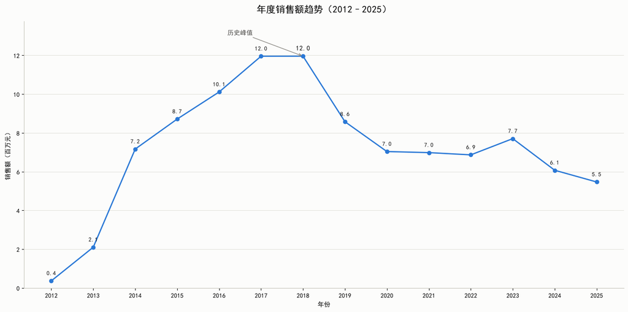

#### Note:该防水保温企业的营收走势，高度跟随房地产开发周期。2012‑2017 年受益房地产扩张实现高速增长，**2018 年达历史峰值（约 1,196 万元）**；2019 年起随新房建设回落（2019 年 858 万元），2020 年后营收中枢下移至 630~720 万元/年；2023 年一度回升至 771 万元，随后再度下滑至 2025 年的 547 万元。后期业务增量，大概率要依赖旧房翻新维修、老房防水改造（存量房市场），而不是新房开发。

```
出货日期
2022-01-01    1350959.33
2022-04-01    1698337.01
2022-07-01    1937532.45
2022-10-01    1881644.05
2023-01-01    1581944.65
2023-04-01    1934198.08
2023-07-01    2205079.16
2023-10-01    1984481.84
2024-01-01    1097060.13
2024-04-01    1908480.89
2024-07-01    1632538.05
2024-10-01    1436492.63
2025-01-01    1166316.64
2025-04-01    1711211.56
2025-07-01    1479994.23
2025-10-01    1112359.05
Freq: QS-JAN, Name: 合计, dtype: float64
```

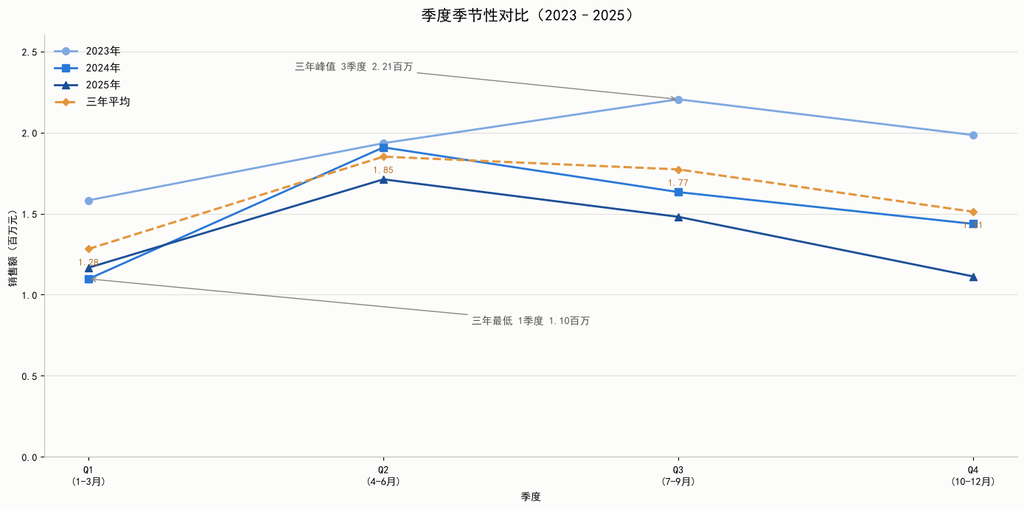

### 2、客户营收维度分析

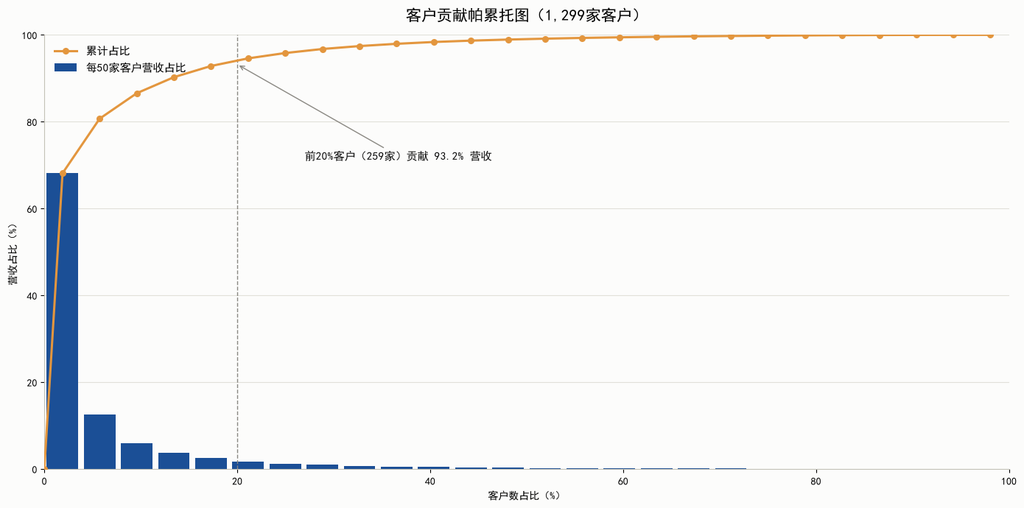

#### Note:客户贡献高度集中：**前 50 家客户撑起约 68% 营收，前 20% 客户（259 家）贡献 93.2% 营收**，远超帕累托二八定律；客户集中度极高，1-2 家核心客户流失即可对营业额造成较大打击。

### 3、订单营收维度分析

```
count     89593.0
mean       1163.0
std        3435.0
min           0.0
50%         372.0
75%        1213.0
90%        2650.0
95%        3906.0
99%       11530.0
max      291458.0
Name: 合计, dtype: float64
```

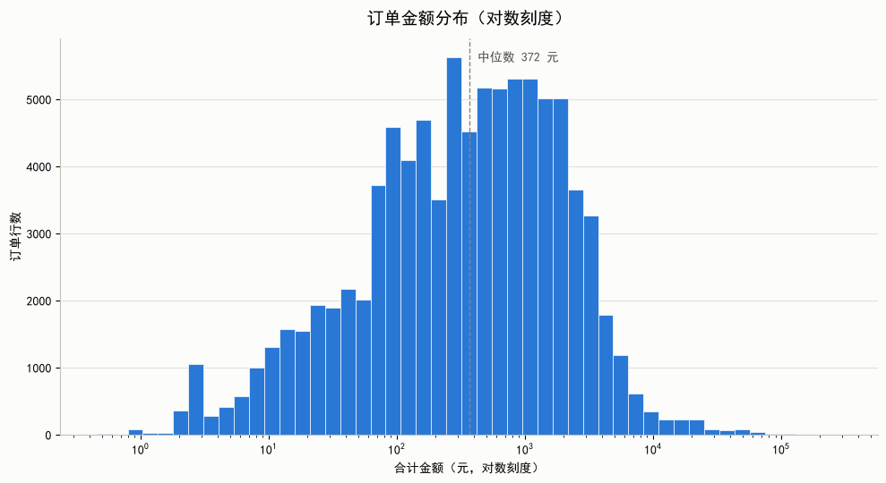

```
分箱完整统计：
```

| 订单等级 | count | sum | 订单数占比 | 营收占比 |
| --- | --- | --- | --- | --- |
| 0‑100元(小额散单) | 23759 | 1.01 百万 | 26.52% | 0.97% |
| 100‑1000元(中小单) | 39694 | 16.45 百万 | 44.30% | 15.79% |
| 1000‑10000元(中型工程) | 25071 | 61.42 百万 | 27.98% | 58.96% |
| ≥10000元(大型工程) | 1069 | 25.29 百万 | 1.19% | 24.28% |

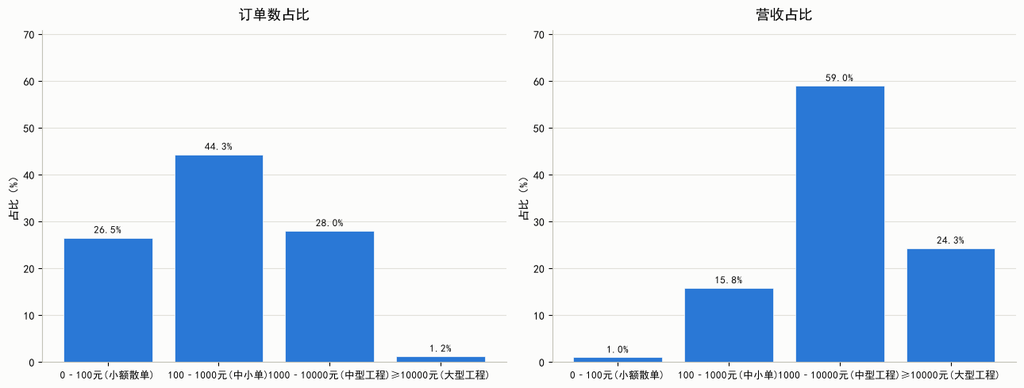

#### Note:订单金额呈现明显右偏长尾分布：中位数 372 元、均值 1,163 元，少数大单大幅拉高均值。订单数量集中于 100‑1000 元区间（44.3%），但 **1,000 元以上订单仅占 29.2% 数量、贡献 83.2% 营收**；其中 ≥10,000 元的工程大单仅 1,069 笔（1.2% 数量）却贡献 **24.3% 营收**——小额散单是流量，大额工程单才是营收与回款的关键。

### 4、品类营收分析

| 品类 | 营收万 | 占比% | 销量 | 均价 | 行数 |
| --- | --- | --- | --- | --- | --- |
| 邓禄普系列 | 7,695 | 73.900000 | 1,407,130 | 54.700000 | 46,924 |
| 晨阳水漆系列 | 1,449 | 13.900000 | 109,261 | 132.700000 | 14,950 |
| 祥得士系列 | 252 | 2.400000 | 110,186 | 22.900000 | 4,449 |
| 辅料类 | 172 | 1.600000 | 384,166 | 4.500000 | 12,643 |
| 奥佳防水材料 | 137 | 1.300000 | 96,705 | 14.200000 | 258 |
| 其它防水材料 | 134 | 1.300000 | 31,286 | 42.800000 | 425 |
| 东方雨虹防水材料 | 91 | 0.900000 | 28,474 | 31.900000 | 51 |
| 金威防水材料 | 83 | 0.800000 | 14,225 | 58.400000 | 1,492 |
| 亚士漆 | 66 | 0.600000 | 6,079 | 108.000000 | 394 |
| 基膜类 | 55 | 0.500000 | 3,448 | 158.800000 | 346 |

```
TOP10 合计占比：97.3%
```

[figure not shown]

#### Note:品类结构高度集中：**邓禄普系列一家占 73.9% 营收**，TOP3 品类合计 90.2%，TOP10 合计 97.3%——营收几乎全部由前 10 个品类贡献，尾部 26 个品类合计约 2.7%。邓禄普系列以最大销量（140.7 万单位）叠加不低的均价（54.7 元）造就一枝独秀；晨阳水漆系为高客单品类（均价 132.7 元），辅料类则相反——销量第二（38.4 万单位）但均价仅 4.5 元，属低值高频的配件耗材。单一品牌依赖是营收最大的结构性风险。

### 5、业务建议

**4、订单维度：结构分化** —— 千元以上订单仅 29.2% 数量，却贡献 83.2% 营收。 → **对策**：重点维护工程大单客户，小额散单控制成本即可。

*数据口径：以上数字均基于清洗后数据（89,593 行），与前述各小节口径一致。*

## 三、交叉分析

单变量分析已分别看清时间、客户、订单、品类四个维度的结构。本节把维度两两交叉，用多维度的方式分析以下四个问题：

1. [客户 × 品类]：交叉购买与品类联动
2. [品类 × 时间]：增长衰退与季节模式
3. [客户 × 欠款]：四象限分级，识别用户风险
4. [时间 × 客户流]：客户生命周期分析

### 1、客户 × 品类：交叉购买与品类联动

```
真实客户数：1298 家；零售占位 6502 行、196.8 万（占 1.9%）
TOP20 客户营收 5065 万，占真实客户营收 49.6%
```

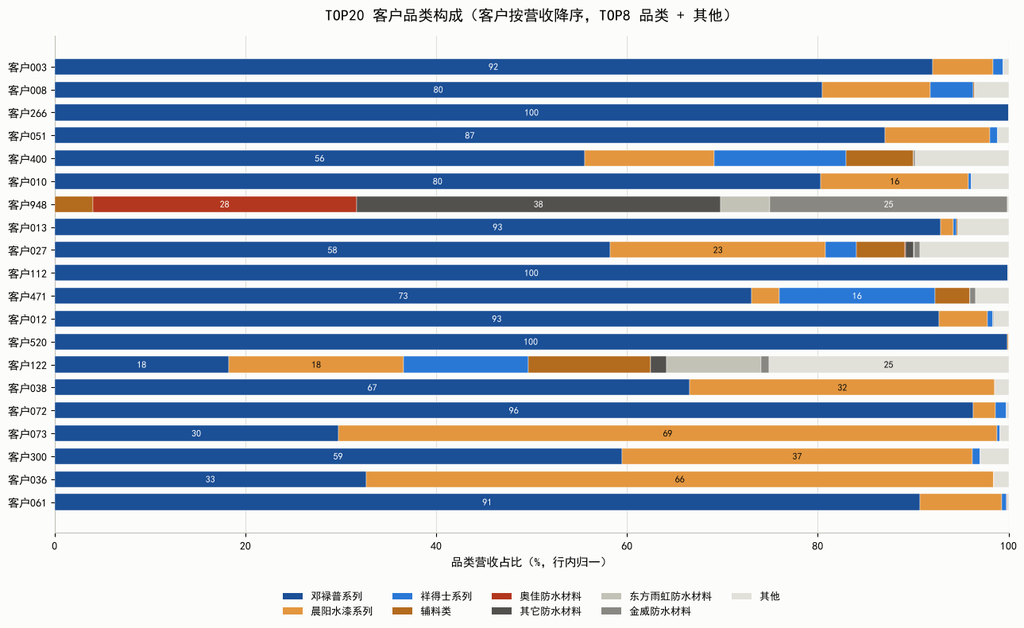

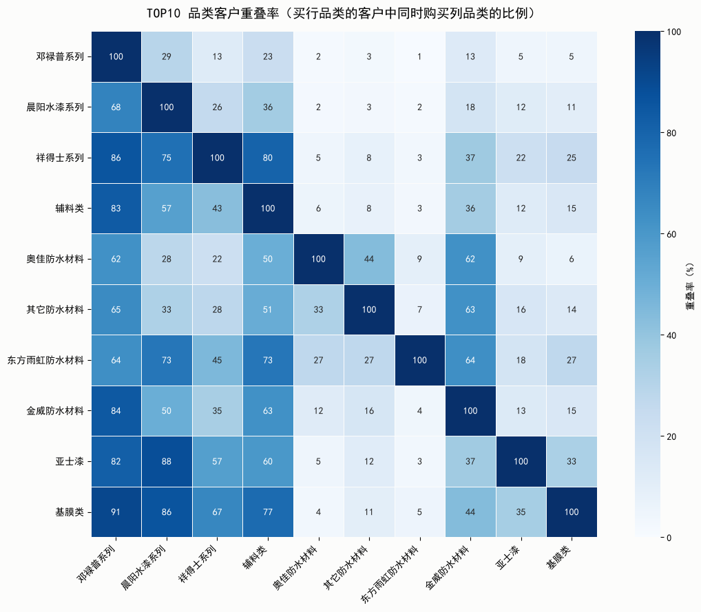

#### Note:

客户品类结构高度集中，交叉购买主要发生在**辅料与防水材料内部**：

- **TOP20 客户营收 5,065 万（占真实客户营收 49.6%）**，头部客户高度依赖单一品类——前 5 大客户中 3 家邓禄普占比超 85%，第三名客户 更是 100% 依赖邓禄普
- 品类联动最强者为**祥得士系列 × 辅料类（80.4%）**——买祥得士的客户中八成同时买辅料；防水材料内部交叉明显（买东方雨虹的客户 63.6% 也买金威防水）
- **邓禄普客户（1,040 家）第二品类渗透率有限**：晨阳水漆 29.4%、辅料 23.1%、金威防水 13.3%——交叉销售空间仍大，可向邓禄普客户重点推"防水 + 辅料"组合，支撑培育第二品类

*口径：客户维度排除"零售"占位（6,502 行、196.8 万，仅占营收 1.9%）；重叠率 = 买品类 A 的客户中同时买 B 的比例；金额按折后合计。*

### 2、品类 × 时间：增长衰退与季节模式

把品类结构与时间轴交叉，回答：**2023→2025 连续下滑（-29.0%）是普跌还是结构性？** Q1 淡季由哪些品类主导？

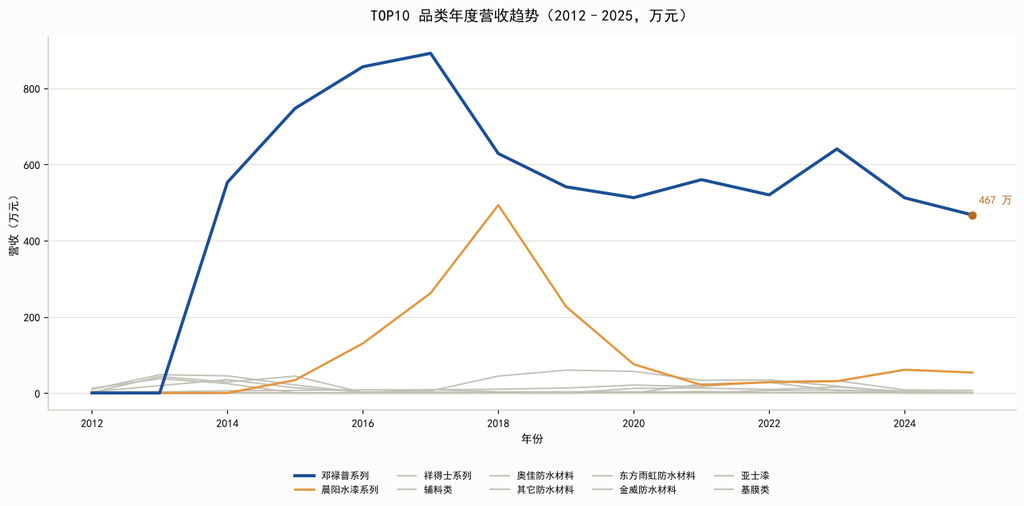

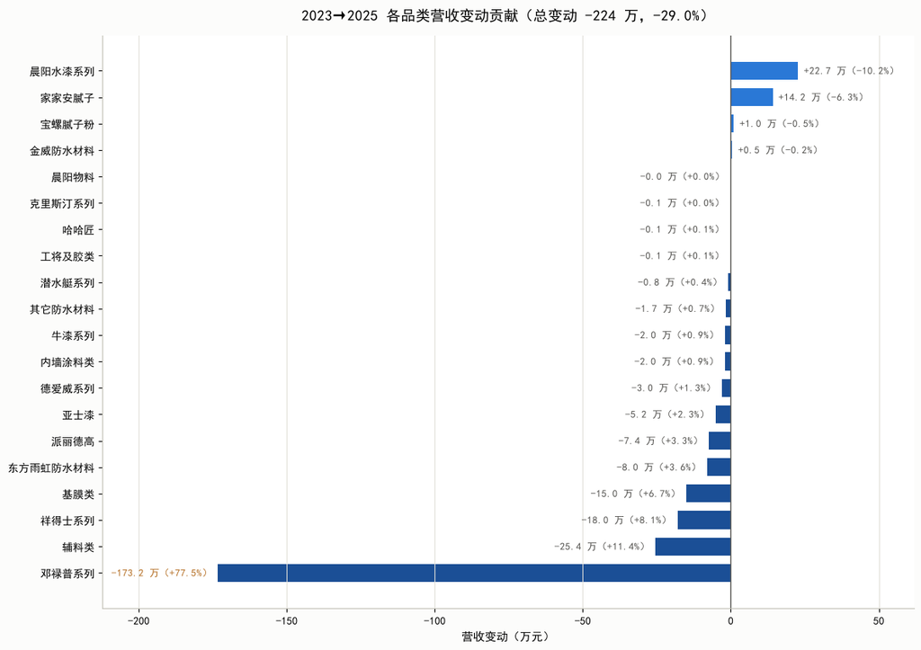

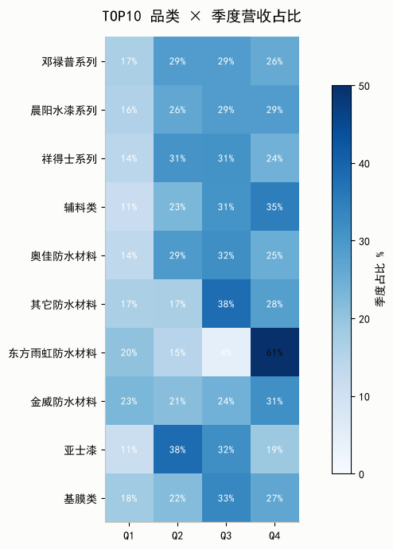

#### Note:

**2023→2025 的 224 万下滑（-29.0%）是"邓禄普主导 + 退市品类萎缩"的结构性下跌，不是全面普跌：**

- **邓禄普系列一家贡献 78% 的降幅**：2023 年 641 万 → 2025 年 467 万（**-173 万**）。只看最近一年（2024→2025，-60 万/-10.0%）结论不变——邓禄普仍贡献 74% 的降幅，跨口径稳健
- **其余品类净贡献仅 -50 万（占降幅 22%）**，且主要是退市/收缩品类：辅料 -25 万、祥得士 -18 万、基膜 -15 万——属品牌迭代或产品线退出，而非需求消失
- **逆势增长证明需求在迁移而非消失**：晨阳水漆 +23 万、家家安腻子 +14 万，客户正流向替代品牌
- **季节性无结构性例外**：多数品类 Q1 为全年最低（占比 11%~23%，全品类 Q1 仅 16.4%），Q2–Q3 施工旺季主导；辅料类 Q4 偏高（35%）带年末备货特征

*口径：完整年度 2012–2025；金额按折后合计；2023→2025 累计口径与 2.1 时间序列一致（771→547 万，-29.0%）；贡献占比 = 品类变动额 ÷ 总变动额；季节占比为品类内行归一化。*

### 3、客户 × 欠款：四象限分级

把客户按**累计营收**与**欠款率**交叉分成四象限，回答：**赊销风险集中在谁身上？** 哪些客户是优质客户，哪些是风险客户？

```
整体欠款率 15.99%；前20%客户边界营收 4.2 万（259 家）
```

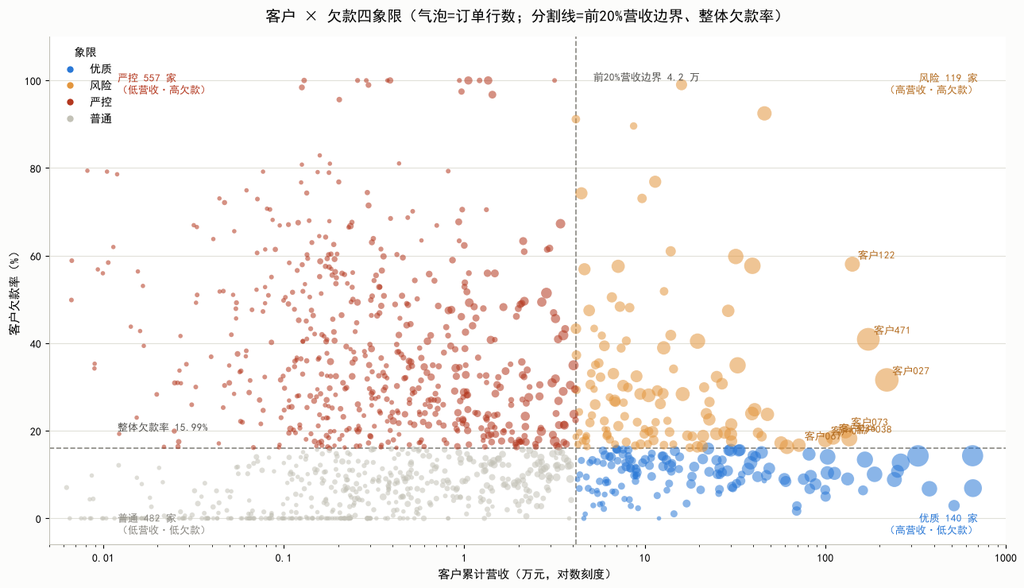

| 象限 | 客户数 | 营收万 | 欠款万 | 客户占比% | 营收占比% | 欠款占比% | 欠款率% |
| --- | --- | --- | --- | --- | --- | --- | --- |
| 风险 | 119 | 2,661 | 812.7 | 9.200000 | 26.000000 | 49.700000 | 30.550000 |
| 优质 | 140 | 6,854 | 658.4 | 10.800000 | 67.100000 | 40.300000 | 9.610000 |
| 严控 | 557 | 390 | 136.3 | 42.900000 | 3.800000 | 8.300000 | 34.910000 |
| 普通 | 482 | 314 | 26.7 | 37.100000 | 3.100000 | 1.600000 | 8.490000 |

```
风险象限欠款额 TOP3（管控优先级）：
  客户122：欠款 82.0 万（欠款率 58.0%，营收 141 万）
  客户471：欠款 70.8 万（欠款率 40.9%，营收 173 万）
  客户027：欠款 69.4 万（欠款率 31.6%，营收 219 万）
```

#### Note:

**赊销风险高度集中：119 家风险客户（9.2% 客户数）持有 49.7% 的欠款（812.7 万）**，而它们的营收只占 26.0%（2,661 万）、平均欠款率 30.55%——大额赊销集中在少数大客户身上：

- **优质象限（140 家，营收 67.1%）：大客户整体回款健康**，平均欠款率 9.61%；**营收前 10 大客户中 9 家位于优质象限**（欠款率 ≤ 14.3%），仅客户027 落入风险象限（欠款率 31.6%），基本盘稳固
- **风险象限（119 家）是管控靶心**：按欠款额排序，**客户122（欠款 82.0 万、欠款率 58.0%）、客户471（70.8 万、40.9%）、客户027（69.4 万、31.6%）** 合计 222 万，占风险象限欠款的 27%——先清这三家，应收账款立减约四分之一
- **严控象限（557 家）**：低营收（合计 390 万）但欠款率高达 34.91%、欠款 136.3 万——客户体量小、催收成本高，**停止新增赊销、转现金或小额授信**即可止血
- **普通象限（482 家）**：欠款率 8.49%，欠款仅占全部欠款的 1.6%

*口径：客户维度排除"零售"占位；欠款率阈值 = 客户口径整体 15.99%；营收边界 = 前 20% 客户（第 259 名）营收 4.2 万；气泡 = 订单行数（sqrt 缩放）；客户名称为脱敏编号假名。*

### 4、时间 × 客户流：留存 / 新客 / 流失分解

把客户维度和时间轴交叉，回答：**2025 年下滑主要是老客流失，还是新客不足？** 客户的"生命周期"有多长？

```
新客营收占比：2025 年 6.1%（2014 年 75.7%）
```

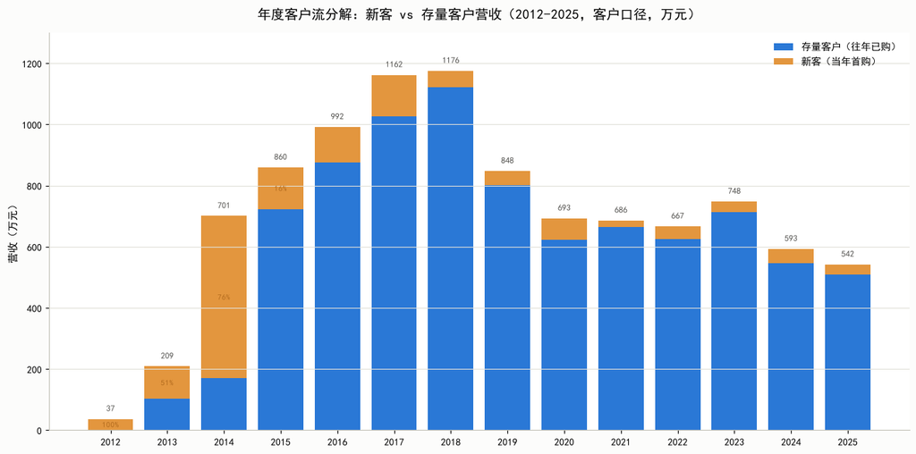

```
各 同期群 第 2/3/5 年留存均值：46.7% / 31.0% / 18.9%
2024 同期群 第 2 年留存 52%（2023 同期群 为 46%）
```

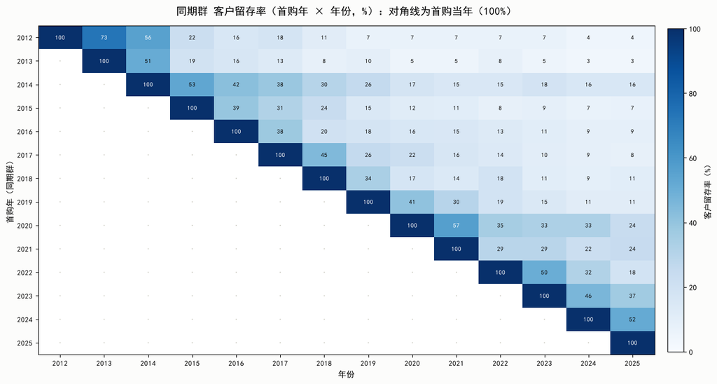

```
首购 2012-2024 共 1240 家：仅活跃 1 年 581 家（46.9%，营收占 2.3%）
活跃 ≥6 年 171 家（13.8%）贡献营收 78.9%
```

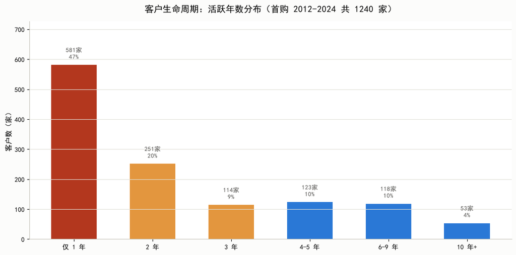

#### Note:

**2025 下滑 = 老客流失 + 新客不足 + 存量缩量，三因叠加；其中流失市场规模的缺口大于新客补量，是核心矛盾：**

- **① 增长期靠新客，成熟期吃存量**：2013-2017 高速增长由新客驱动（2014 年 303 家新客贡献 530.3 万、占当年 75.7%）；2018 年起新客占比骤降至个位数（2025 年仅 46 家 / 33.3 万、6.1%）——存量客户成为营收基本盘
- **② 单年分解（2024→2025，客户口径 -50.9 万）**：流失 67 家（2024 贡献 55.6 万）> 新客 46 家（33.3 万）——流失盘子比新客补量多 22.3 万；老客回流 30 家仅 +7.7 万；存量客户净缩 36.3 万（82 家缩量 131.9 万 vs 62 家增长 95.5 万），2025 年销量下滑实际是"老客流失 + 新客补不上 + 存量老客户买得少"三重因素。
- **③ 同期群留存常年偏低**：各同期群第 2 / 3 / 5 年客户留存均值仅 **46.7% / 31.0% / 18.9%**——3 年后只剩约 1/3 客户还活跃；2024第 2 年留存 52%（2023 为 46%，略有改善，但体量太小）。
- **④ 客户生命周期严重分化**：首购 2012-2024 的 1,240 家客户中，**46.9%（581 家）仅活跃 1 年、营收只占 2.3%**（一次性工程/流动客户）；而活跃 ≥6 年的 171 家（13.8%）贡献 **78.9% 营收**——长情客户是绝对基本盘。

> **业务落点**：下滑不是需求消失，而是客户"进得少、留不住、老客缩量"。营收的 8 成系于少数长情客户，建议：① 一定要通过回访、售后等方式保住少数老客户，否则1-2家老客户流失都会对业务营收产生较大打击；② 提升"仅 1 年客户"的次活跃率（46.9% 转化率哪怕 +5% 都相当于多了约 60 家客户的营收）。

*口径：客户维度排除"零售"占位；活跃 = 当年有订单；首购年 = 客户首笔订单年份（用全历史 2007-2025 判定）；年度为完整年度 2012-2025；留存率 = 该同期群客户在后续年仍活跃的比例（客户数口径）*